# Hyne - Logs - Green and Dry

JH

```r
library(lattice)
library(RODBC)
ch = odbcConnect('Hyne',uid='sa',pwd="password12")

mypanel = function(x,y,...) {
  panel.abline(c(0,1), col='grey70', lty=2)
  panel.xyplot(x,y,...)
}

B = sqlQuery(ch, "
             select
                SWILogNumber,
                g.MOE [E.g],
                g.Density [den.g],
                m.swv [v.d.hitman],
                h.[Density_kg/m3] [den.d.lhg],
                h.[MOE.cltraw] [E.d.clt],
                m.pith,
                m.wane,
                m.bow,
                m.crook,
                m.twist,
                X_Dens [den.d.chh],
                X_Clear [den.d.chh.clear],
                X_DynE [E.d.chh.dyn],
                X_AvgE [E.d.chh.avg],
                X_MOE [E.d.chh.moe]
             from (
                select flitchId, max(pith) pith, max(wane) wane, avg(swv) swv, avg(bow) bow, avg(crook) crook, avg(twist) twist
                from manualMeas group by flitchId
             ) m
             left join CHHBoards c on c.flitchId=m.flitchId
             left join HyneDryBoards h on h.flitchId=m.flitchId
             left join ecoustic g on m.flitchId=g.flitchId
             left join (
                select flitchId, max(SWILogNumber) SWILogNumber
                from boardEndImages i, barcode_image bi, boardEndBarcodes b
                where flitchId is not null and i.id=bi.imageId and bi.barcodeId=b.id group by flitchId
             ) f on f.flitchId=m.flitchId
             ")
B$pith_wane = paste(B$pith,B$wane)
B$E.d.hitman = B$v.d^2*B$den.d.chh/1e9

# halve the SWV for ridiculosly fast ecoustic velocities
B$v.g = sqrt(B$E.g*1e9/B$den.g)
B$E.g.corrected = B$E.g
ii=!is.na(B$v.g) & B$v.g>4000
B$E.g.corrected[ii] = (B$v.g[ii]/2)^2*B$den.g[ii]/1e9

nrow(B)
```

```
## [1] 1202
```

1202 boards. 62 not associated with a SWILogNumber.

```r
L = sqlQuery(ch, "
             select
               p.*,
               s.*,
               u.SWV [SWV.untrimmed],
               t.SWV [SWV],
               t.weight,
               3.141592654*4.9/3*(rL*rL+rS*rL+rS*rS) [volume.heart]
             from
               (select * from logs where SWILogNumber is not null and DateAndTime>'2014-08-31 00:00:00') p
               left join (select * from logs where SWILogNumber is not null and DateAndTime<'2014-08-31 00:00:00') s
                 on s.SWILogNumber=p.SWILogNumber
               left join yardTrimmed t on p.SWILogNumber=t.SWILogNumber
               left join yardUntrimmed u on p.SWILogNumber=u.SWILogNumber
               left join (select
                            l.SWILogNumber, l.heartwoodDiameter_mm/2000 rL, s.heartwoodDiameter_mm/2000 rS
                            from logends l, logends s where s.SWILogNumber=l.SWILogNumber and s.logEnd='S' and l.logEnd='L'
               ) h on h.SWILogNumber=p.SWILogNumber
             order by p.SWILogNumber")
for (i in 1:nrow(L)) {
  ii=!is.na(B$SWILogNumber) & B$SWILogNumber==L[i,"SWILogNumber"]
  L[i,"nboards"]=sum(ii)
  L[i,"E.avg"]=mean(B$E.d.clt[ii],na.rm=TRUE)
  L[i,"E.avg.dyn"]=mean(B$E.d.hitman[ii],na.rm=TRUE)
  L[i,"GPa10"]=sum(!is.na(B$E.d.hitman) & B$E.d.hitman>=10 & ii)/sum(ii)
  L[i,"GPa8"]=sum(!is.na(B$E.d.hitman) & B$E.d.hitman>=8 & ii)/sum(ii)
  L[i,"GPa6"]=sum(!is.na(B$E.d.hitman) & B$E.d.hitman>=6 & ii)/sum(ii)
  L[i,"npith"]=sum(ii & (!is.na(B$pith) & B$pith=='y'))
  L[i,"bow_avg"]=mean(B$bow[!is.na(B$bow) & ii])
  L[i,"bow_50"]=median(B$bow[!is.na(B$bow) & ii])
  L[i,"bow_75"]=quantile(B$bow[!is.na(B$bow) & ii], 0.75)
  L[i,"crook_avg"]=mean(B$crook[!is.na(B$crook) & ii])
  L[i,"crook_50"]=median(B$crook[!is.na(B$crook) & ii])
  L[i,"crook_75"]=quantile(B$crook[!is.na(B$crook) & ii], 0.75)
  L[i,"twist_avg"]=mean(abs(B$twist[!is.na(B$twist) & ii]))
  L[i,"twist_50"]=median(abs(B$twist[!is.na(B$twist) & ii]))
  L[i,"twist_75"]=quantile(abs(B$twist[!is.na(B$twist) & ii]), 0.75)
}

# calibre uses 0 to indicate missing
L$velocity[L$velocity==0]=NA
L$velocity.1[L$velocity.1==0]=NA

L$hw.vfrac = L$volume.heart / L$volume
L$density = L$weight / L$volume

L$sweep.prod = L$m_sweep1*L$m_sweep2
L$sweep.prod.1 = L$m_sweep1.1*L$m_sweep2.1

#str(L)
```

Why are the shape metrics (`m_*`) missing for 10 logs? 9 of these logs (198,201,208,195,205,148,194,206,207) were the first put through, maybe the logselect software wasn’t running. The 10th is a log that for some reason couldn’t be matched to Royalty scanner Id (or perhaps no nin file matching that Id was available)

Hitman SWV isn’t available for the last trimmed log (223). Can we use untrimmed hitman swv?

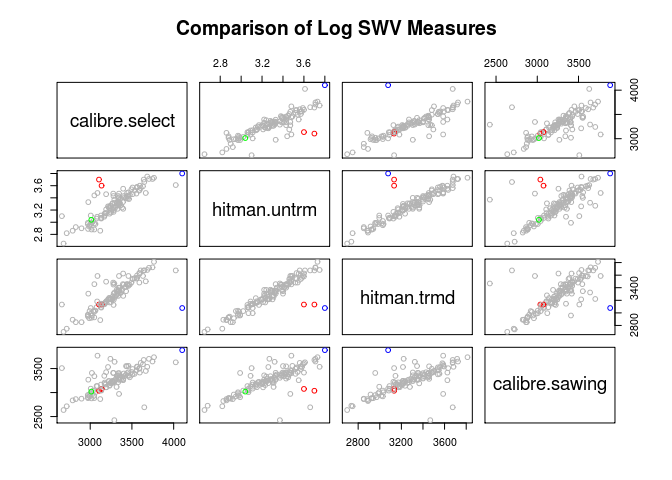

```r
#plot(L$SWV,L$SWV.untrimmed*1000.)
#identify(L$SWV,L$SWV.untrimmed*1000.,L$SWILogNumber)
c=rep('grey70',nrow(L))
c[L$SWILogNumber %in% c(157,183)]='red'
c[L$SWILogNumber %in% c(151)]='blue'
c[L$SWILogNumber %in% c(223)]='green'
tmp=L[,c("velocity","SWV.untrimmed","SWV","velocity.1")]
names(tmp)<-c("calibre.select","hitman.untrm","hitman.trmd","calibre.sawing")
pairs(tmp,col=c,main="Comparison of Log SWV Measures")
```

Three outliers (logs 151,157,183).

Trimmed SWV estimate good for logs 157, 183 (i.e. untrimmed SWV wrong).

Use hitman untrimmed estimate for log 151.

Use hitman untrimmed estimate for log 223.

TODO: re-extract hitman SWV from raw hitman data.

```r
L$SWV[L$SWILogNumber==151] = L$SWV.untrimmed[L$SWILogNumber==151]*1000
L$SWV[L$SWILogNumber==223] = L$SWV.untrimmed[L$SWILogNumber==223]*1000
```

Do the two measures of volume/LED/SED agree?

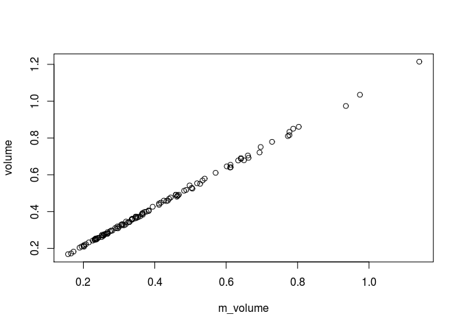

```r
plot(volume ~ m_volume, L)
```

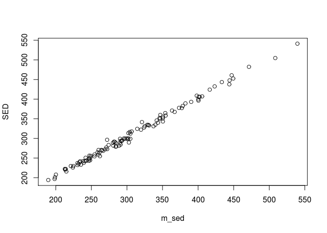

```r
plot(SED ~ m_sed, L)
```

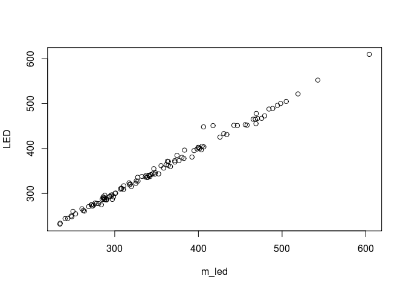

```r
plot(LED ~ m_led, L)
```

Yep, pretty much.

Is the heartwood volume stuff sane?

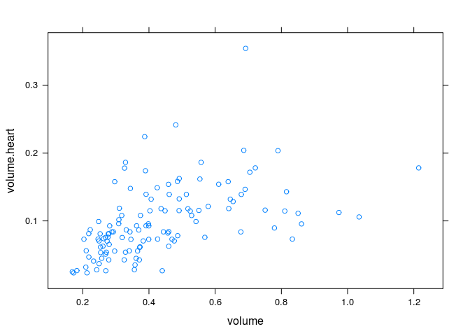

```r
xyplot(volume.heart ~ volume, L)
```

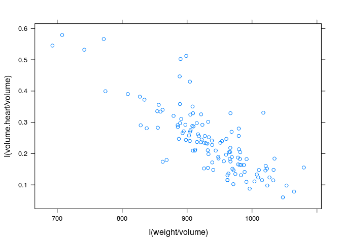

```r
xyplot(I(volume.heart/volume) ~ I(weight/volume), L)
```

```r
summary(lm(I(weight/volume) ~ I(volume.heart/volume), L))
```

```
##
## Call:
## lm(formula = I(weight/volume) ~ I(volume.heart/volume), data = L)
##
## Residuals:
##      Min       1Q   Median       3Q      Max
## -105.612  -23.525   -5.409   19.012  130.911
##
## Coefficients:
##                        Estimate Std. Error t value Pr(>|t|)
## (Intercept)            1058.725      8.902  118.93   <2e-16 ***
## I(volume.heart/volume) -520.867     34.059  -15.29   <2e-16 ***
## ---
## Signif. codes:  0 '***' 0.001 '**' 0.01 '*' 0.05 '.' 0.1 ' ' 1
##
## Residual standard error: 39.78 on 121 degrees of freedom
## Multiple R-squared:  0.659,  Adjusted R-squared:  0.6562
## F-statistic: 233.9 on 1 and 121 DF,  p-value: < 2.2e-16
```

Regression suggests average sapwood density of 1058 kg/m^3, with average heartwood density of 537 kg/m^3.

Compare log metrics computed at selection and processing time (i.e. before and after being trimmed to 4.9m):

[figure not shown]

```r
par(mfcol=c(4,4))
log.metrics = c("m_volume","m_led","m_sed","m_taper","m_waist","m_ovality","m_whorliness","m_a0","m_a1","m_a2","m_sweep1","m_sweep2","sweep.prod")
for (m in log.metrics) {
  plot(formula(paste(m,"~",m,".1",sep="")),L)
  }
```

For the most part log metrics are similar before and after trimming. Where differences do occur it might be due to the loss of material or to un-repeatability.

## Recovery

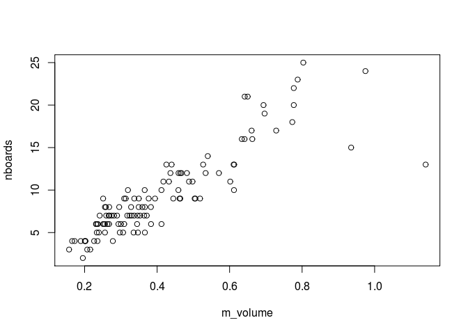

```
## integer(0)
```

```r
plot(nboards ~ m_volume, L)
identify(L$m_volume, L$nboards, L$SWILogNumber, cex=0.8)
```

Exclude these logs from further analysis.

```r
L = L[!L$SWILogNumber%in%c(106,126,192),]
```

## Stiffness Out-turn

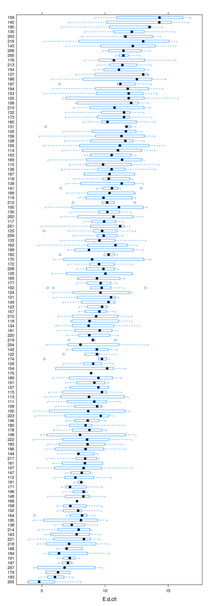

```r
bwplot( factor(SWILogNumber,levels=L$SWILogNumber[order(L$E.avg)],ordered=TRUE) ~ E.d.clt, B)
```

```r
# and again but with only the best and worst and with individual boards
(worst=L$SWILogNumber[L$E.avg<quantile(L$E.avg,0.1)])
```

```
##  [1] 101 163 168 179 184 187 193 205 207 214 218 221
```

```r
(best=L$SWILogNumber[L$E.avg>quantile(L$E.avg,0.9)])
```

```
##  [1] 135 140 143 154 159 176 190 200 203 206 213 216
```

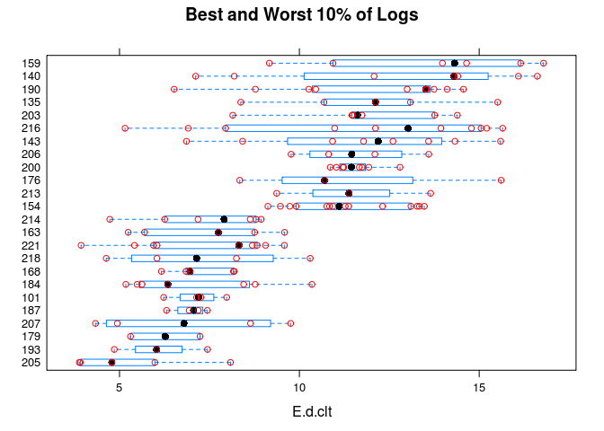

```r
bwplot( factor(SWILogNumber,levels=L$SWILogNumber[order(L$E.avg)],ordered=TRUE) ~ E.d.clt, B,subset=SWILogNumber %in% union(best,worst),
        panel=function(...){
          panel.bwplot(...)
          panel.points(...,col='red')
        }, main="Best and Worst 10% of Logs")
```

The worst (least stiff) boards are similar across all logs. The best (most stiff) boards howver range from <10 GPa to >15GPa.

Are good logs small?

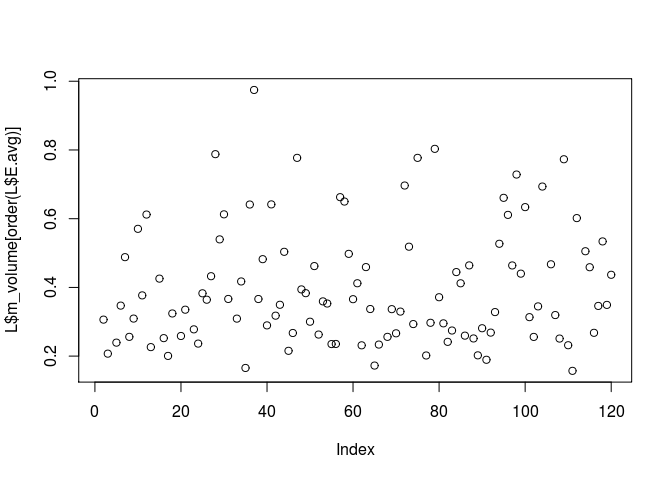

```r
plot(L$m_volume[order(L$E.avg)])
```

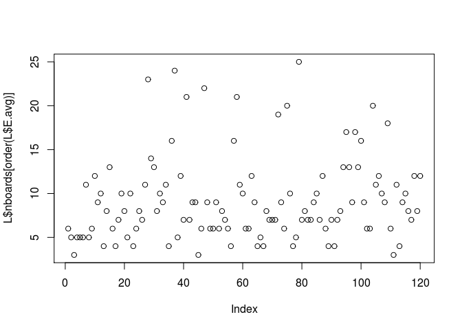

```r
plot(L$nboards[order(L$E.avg)])
```

Bad logs tend to be both a little smaller and represented by fewer boards, but the effect is not strong.

## Grade

Note that ‘GPax’ here denotes boards whose average MOE is x GPa or better, which is not really the same as having a GPax grade.

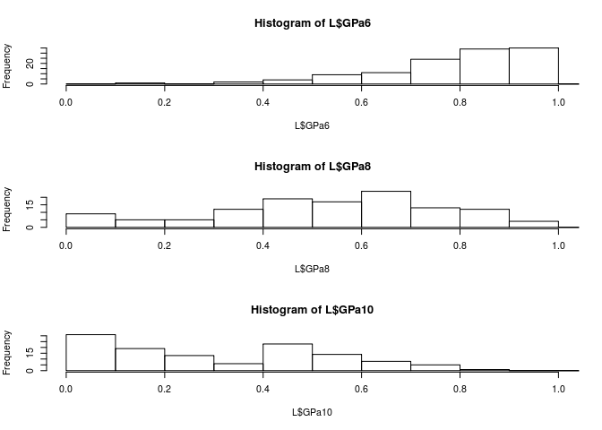

```r
par(mfcol=c(3,1))
hist(L$GPa6, xlim=c(0,1), breaks=c(0:11)/10)
hist(L$GPa8, xlim=c(0,1), breaks=c(0:11)/10)
hist(L$GPa10, xlim=c(0,1), breaks=c(0:11)/10)
```

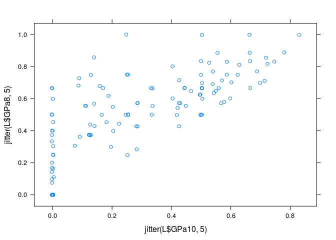

```r
xyplot(jitter(L$GPa8,5)~jitter(L$GPa10,5))
```

Interesting that the 5 best logs if seeking GPa8 include one log that would be in the lower half if you were looking for GPa10.

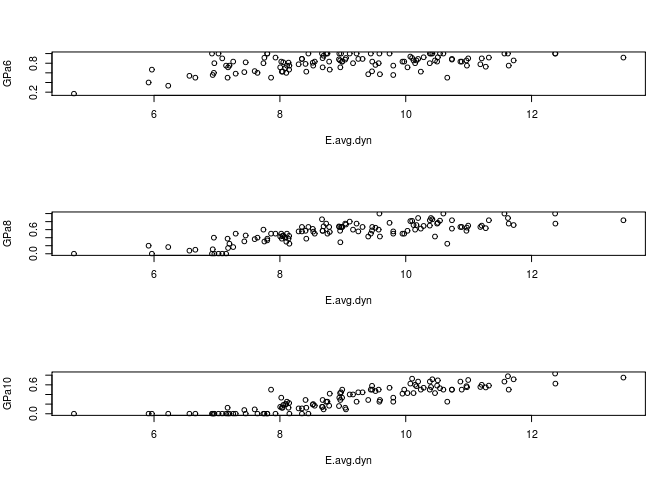

```r
par(mfcol=c(3,1))
plot(GPa6~ E.avg.dyn, L)
plot(GPa8~ E.avg.dyn, L)
plot(GPa10~ E.avg.dyn, L)
```

Log average MOE is not necessarily a good predictor of fraction of boards exceeding a particular MOE limit.

## Marco’s Proposal Statement

How does the fraction GPa10+ vary with log quality? I.e. what is the % of GPa10+ in the worst X% of logs?

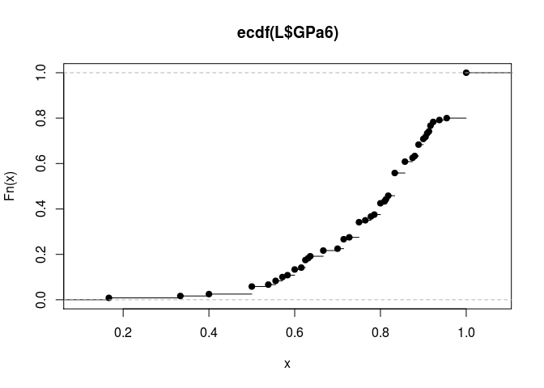

```r
par(mfcol=c(1,1))
F=ecdf(L$GPa6)
plot(F)
```

```r
quantile(L$GPa6, 0.05)
```

```
##  5%
## 0.5
```

```r
quantile(L$GPa6, 0.10)
```

```
##       10%
## 0.5821429
```

TODO: using a model for log stiffness based on pre-sawing measures, redo this.

## Dynamic v Static

Does it matter if we use Hitman instead of CLT results?

### Using hitman and CHH density

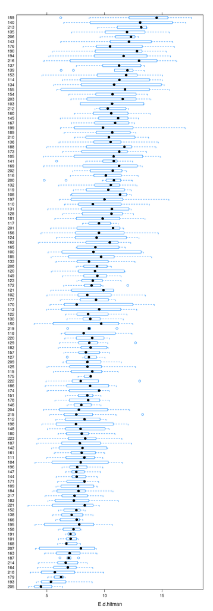

```r
bwplot( factor(SWILogNumber,levels=L$SWILogNumber[order(L$E.avg.dyn)],ordered=TRUE) ~ E.d.hitman, B)
```

```r
# and again but with only the best and worst and with individual boards
(worst.dyn=L$SWILogNumber[L$E.avg<quantile(L$E.avg,0.1)])
```

```
##  [1] 101 163 168 179 184 187 193 205 207 214 218 221
```

```r
(best.dyn=L$SWILogNumber[L$E.avg>quantile(L$E.avg,0.9)])
```

```
##  [1] 135 140 143 154 159 176 190 200 203 206 213 216
```

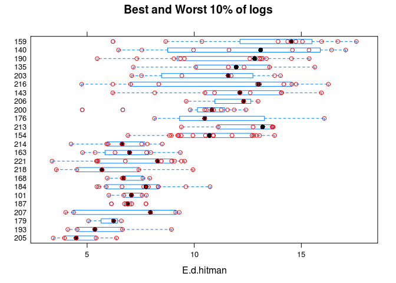

```r
bwplot( factor(SWILogNumber,levels=L$SWILogNumber[order(L$E.avg)],ordered=TRUE) ~ E.d.hitman, B,subset=SWILogNumber %in% union(best.dyn,worst.dyn),
        panel=function(...){
          panel.bwplot(...)
          panel.points(...,col='red')
        }, main="Best and Worst 10% of logs")
```

```r
intersect(best, best.dyn)
```

```
##  [1] 135 140 143 154 159 176 190 200 203 206 213 216
```

```r
intersect(worst, worst.dyn)
```

```
##  [1] 101 163 168 179 184 187 193 205 207 214 218 221
```

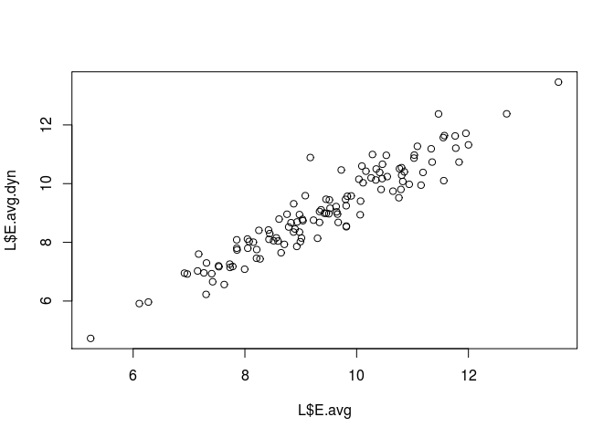

```r
plot(L$E.avg,L$E.avg.dyn)
```

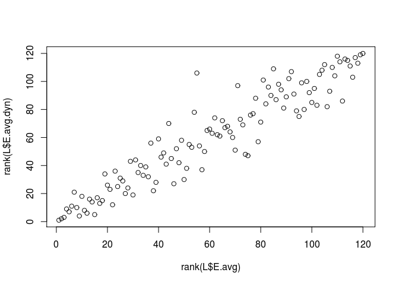

```r
plot(rank(L$E.avg),rank(L$E.avg.dyn))
```

From here on use Hitman and CHH density based board and log average MOE.

## Pith Boards

Do all logs have a similar number of pith-in boards?

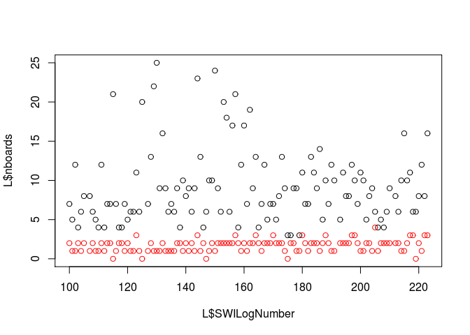

```r
plot(L$SWILogNumber, L$nboards, ylim=c(0,max(L$nboards)))
points(L$SWILogNumber, L$npith, col='red')
```

```r
table(L$npith)
```

```
##
##  0  1  2  3  4
##  5 43 58 13  1
```

```r
L$SWILogNumber[L$npith==0]
```

```
## [1] 115 125 147 175 219
```

Is the fraction of pith boards a good predictor of log average stiffness?

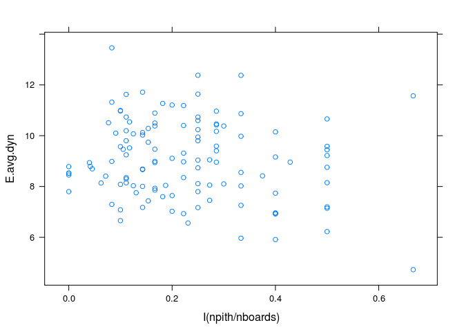

```r
xyplot(E.avg.dyn ~ I(npith/nboards), L)
```

No.

## Board Densities

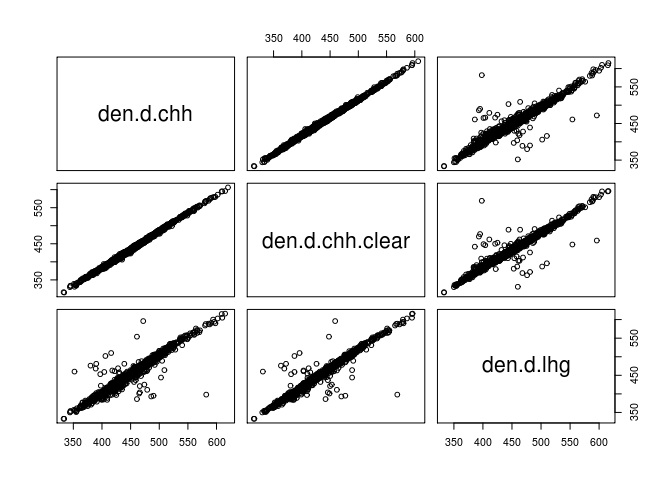

```r
pairs(B[,c('den.d.chh','den.d.chh.clear','den.d.lhg'),])
```

CHH clear (`X_Clear`) and average (`X_Dens`) densities are pretty similar.

Use the latter (`X_Dens`) in conjunction with SWV to estimate MOE.

## Log SWV v average Board MOE

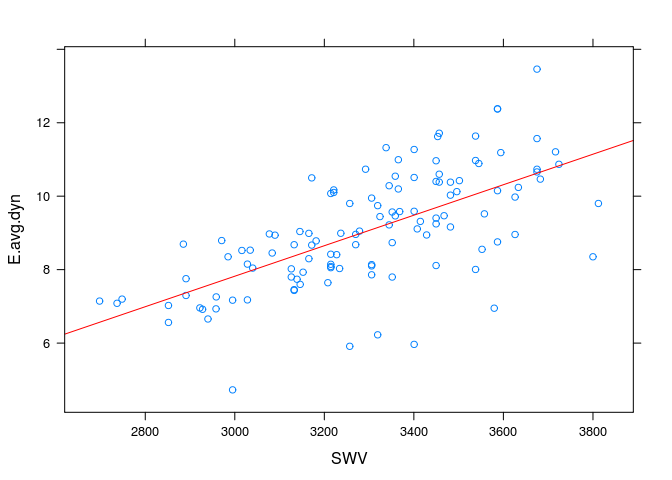

```
##
## Call:
## lm(formula = y ~ x)
##
## Residuals:
##     Min      1Q  Median      3Q     Max
## -3.5195 -0.6276  0.0632  0.7209  2.8354
##
## Coefficients:
##               Estimate Std. Error t value Pr(>|t|)
## (Intercept) -4.6351108  1.4543727  -3.187  0.00184 **
## x            0.0041522  0.0004398   9.441 4.22e-16 ***
## ---
## Signif. codes:  0 '***' 0.001 '**' 0.01 '*' 0.05 '.' 0.1 ' ' 1
##
## Residual standard error: 1.174 on 118 degrees of freedom
## Multiple R-squared:  0.4303, Adjusted R-squared:  0.4255
## F-statistic: 89.14 on 1 and 118 DF,  p-value: 4.216e-16
```

```r
mypanel=function(x,y,...){
  #panel.abline(c(0,1), col='grey70', lty=2)
  panel.xyplot(x,y,...)
  m=lm(y ~ x)
  print(summary(m))
  panel.abline(coef(m),col='red')
}
#xyplot(E.avg ~ SWV, L, panel=mypanel) # hitman in yard
#xyplot(E.avg ~ velocity, L, subset=velocity>0, panel=mypanel) # calibre log tool
xyplot(E.avg.dyn ~ SWV, L, panel=mypanel) # hitman in yard
```

```r
#xyplot(E.avg.dyn ~ velocity, L, subset=velocity>0, panel=mypanel) # calibre log tool
```

Ugly.

Find the best linear model for log average MOE.

```r
summary(m <- lm(E.avg.dyn ~ (m_volume+SWV+m_led+m_sed+m_a0+m_a1+m_a2+m_taper+m_waist+m_ovality+m_whorliness+m_sweep1+m_sweep2+weight+hw.vfrac), L, subset=!is.na(L$m_sed)))
```

```
##
## Call:
## lm(formula = E.avg.dyn ~ (m_volume + SWV + m_led + m_sed + m_a0 +
##     m_a1 + m_a2 + m_taper + m_waist + m_ovality + m_whorliness +
##     m_sweep1 + m_sweep2 + weight + hw.vfrac), data = L, subset = !is.na(L$m_sed))
##
## Residuals:
##     Min      1Q  Median      3Q     Max
## -3.2509 -0.3997 -0.0257  0.4779  1.5447
##
## Coefficients:
##                Estimate Std. Error t value Pr(>|t|)
## (Intercept)  -6.231e+00  2.312e+00  -2.695 0.008338 **
## m_volume     -1.143e+01  6.716e+00  -1.701 0.092233 .
## SWV           4.732e-03  3.865e-04  12.245  < 2e-16 ***
## m_led         3.510e-02  1.543e-02   2.275 0.025159 *
## m_sed        -4.762e-03  1.450e-02  -0.328 0.743307
## m_a0         -2.428e-02  2.419e-02  -1.004 0.318169
## m_a1          1.139e-01  1.612e-01   0.707 0.481588
## m_a2          2.172e-01  1.638e-01   1.327 0.187840
## m_taper      -7.032e-01  7.591e-01  -0.926 0.356639
## m_waist      -8.948e+00  1.100e+01  -0.814 0.417784
## m_ovality     7.253e+01  1.144e+02   0.634 0.527511
## m_whorliness -3.975e-01  3.351e-01  -1.186 0.238467
## m_sweep1     -1.266e-02  1.347e-01  -0.094 0.925286
## m_sweep2     -6.431e-02  9.161e-01  -0.070 0.944189
## weight        9.605e-03  5.118e-03   1.877 0.063664 .
## hw.vfrac     -4.964e+00  1.297e+00  -3.829 0.000232 ***
## ---
## Signif. codes:  0 '***' 0.001 '**' 0.01 '*' 0.05 '.' 0.1 ' ' 1
##
## Residual standard error: 0.794 on 94 degrees of freedom
## Multiple R-squared:  0.7536, Adjusted R-squared:  0.7143
## F-statistic: 19.16 on 15 and 94 DF,  p-value: < 2.2e-16
```

```r
summary(m.best <- step(m, direction="both"))
```

```
## Start:  AIC=-36.04
## E.avg.dyn ~ (m_volume + SWV + m_led + m_sed + m_a0 + m_a1 + m_a2 +
##     m_taper + m_waist + m_ovality + m_whorliness + m_sweep1 +
##     m_sweep2 + weight + hw.vfrac)
##
##                Df Sum of Sq     RSS     AIC
## - m_sweep2      1     0.003  59.263 -38.035
## - m_sweep1      1     0.006  59.265 -38.030
## - m_sed         1     0.068  59.328 -37.914
## - m_ovality     1     0.254  59.513 -37.571
## - m_a1          1     0.315  59.575 -37.458
## - m_waist       1     0.418  59.677 -37.268
## - m_taper       1     0.541  59.801 -37.041
## - m_a0          1     0.635  59.895 -36.868
## - m_whorliness  1     0.887  60.147 -36.405
## <none>                       59.260 -36.040
## - m_a2          1     1.110  60.369 -36.000
## - m_volume      1     1.824  61.084 -34.705
## - weight        1     2.220  61.480 -33.994
## - m_led         1     3.264  62.524 -32.143
## - hw.vfrac      1     9.243  68.503 -22.096
## - SWV           1    94.526 153.786  66.859
##
## Step:  AIC=-38.03
## E.avg.dyn ~ m_volume + SWV + m_led + m_sed + m_a0 + m_a1 + m_a2 +
##     m_taper + m_waist + m_ovality + m_whorliness + m_sweep1 +
##     weight + hw.vfrac
##
##                Df Sum of Sq     RSS     AIC
## - m_sweep1      1     0.009  59.272 -40.017
## - m_sed         1     0.074  59.337 -39.897
## - m_ovality     1     0.253  59.516 -39.565
## - m_a1          1     0.337  59.599 -39.412
## - m_waist       1     0.424  59.687 -39.250
## - m_taper       1     0.571  59.834 -38.980
## - m_a0          1     0.643  59.906 -38.847
## - m_whorliness  1     1.004  60.267 -38.186
## <none>                       59.263 -38.035
## - m_a2          1     1.192  60.455 -37.844
## - m_volume      1     2.063  61.326 -36.270
```

[output cut: 100 more lines]

```
## - m_whorliness  1     1.216  61.999 -45.069
## + m_waist       1     0.860  59.923 -44.817
## + m_a1          1     0.756  60.027 -44.625
## - m_volume      1     1.750  62.533 -44.126
## + m_ovality     1     0.289  60.494 -43.773
## - m_a2          1     1.987  62.770 -43.710
## + m_sweep2      1     0.089  60.694 -43.410
## - weight        1     2.188  62.971 -43.359
## + m_sed         1     0.035  60.748 -43.312
## + m_sweep1      1     0.001  60.783 -43.249
## - m_a0          1     2.385  63.168 -43.015
## - m_taper       1     3.191  63.974 -41.621
## - m_led         1     4.962  65.745 -38.617
## - hw.vfrac      1    10.426  71.210 -29.834
## - SWV           1   104.472 165.255  62.771
```

```
##
## Call:
## lm(formula = E.avg.dyn ~ m_volume + SWV + m_led + m_a0 + m_a2 +
##     m_taper + m_whorliness + weight + hw.vfrac, data = L, subset = !is.na(L$m_sed))
##
## Residuals:
##     Min      1Q  Median      3Q     Max
## -3.2810 -0.3804  0.0230  0.5119  1.6595
##
## Coefficients:
##                Estimate Std. Error t value Pr(>|t|)
## (Intercept)  -6.139e+00  2.112e+00  -2.906   0.0045 **
## m_volume     -1.009e+01  5.944e+00  -1.697   0.0929 .
## SWV           4.780e-03  3.646e-04  13.110  < 2e-16 ***
## m_led         4.137e-02  1.448e-02   2.857   0.0052 **
## m_a0         -3.677e-02  1.857e-02  -1.981   0.0504 .
## m_a2          5.867e-03  3.244e-03   1.808   0.0736 .
## m_taper      -1.921e-01  8.384e-02  -2.291   0.0241 *
## m_whorliness -4.325e-01  3.058e-01  -1.414   0.1603
## weight        8.878e-03  4.679e-03   1.897   0.0607 .
## hw.vfrac     -5.030e+00  1.215e+00  -4.142 7.22e-05 ***
## ---
## Signif. codes:  0 '***' 0.001 '**' 0.01 '*' 0.05 '.' 0.1 ' ' 1
##
## Residual standard error: 0.7796 on 100 degrees of freedom
## Multiple R-squared:  0.7472, Adjusted R-squared:  0.7245
## F-statistic: 32.85 on 9 and 100 DF,  p-value: < 2.2e-16
```

```r
m.best$anova
```

```
##          Step Df    Deviance Resid. Df Resid. Dev       AIC
## 1             NA          NA        94   59.25986 -36.04030
## 2  - m_sweep2  1 0.003106191        95   59.26296 -38.03454
## 3  - m_sweep1  1 0.009235583        96   59.27220 -40.01740
## 4     - m_sed  1 0.078248157        97   59.35045 -41.87228
## 5 - m_ovality  1 0.250911162        98   59.60136 -43.40822
## 6      - m_a1  1 0.321454593        99   59.92281 -44.81654
## 7   - m_waist  1 0.860445923       100   60.78326 -45.24825
```

```r
m.best <- step(m, direction="backward")
```

```
## Start:  AIC=-36.04
## E.avg.dyn ~ (m_volume + SWV + m_led + m_sed + m_a0 + m_a1 + m_a2 +
##     m_taper + m_waist + m_ovality + m_whorliness + m_sweep1 +
##     m_sweep2 + weight + hw.vfrac)
##
##                Df Sum of Sq     RSS     AIC
## - m_sweep2      1     0.003  59.263 -38.035
## - m_sweep1      1     0.006  59.265 -38.030
## - m_sed         1     0.068  59.328 -37.914
## - m_ovality     1     0.254  59.513 -37.571
## - m_a1          1     0.315  59.575 -37.458
## - m_waist       1     0.418  59.677 -37.268
## - m_taper       1     0.541  59.801 -37.041
## - m_a0          1     0.635  59.895 -36.868
## - m_whorliness  1     0.887  60.147 -36.405
## <none>                       59.260 -36.040
## - m_a2          1     1.110  60.369 -36.000
## - m_volume      1     1.824  61.084 -34.705
## - weight        1     2.220  61.480 -33.994
## - m_led         1     3.264  62.524 -32.143
## - hw.vfrac      1     9.243  68.503 -22.096
## - SWV           1    94.526 153.786  66.859
##
## Step:  AIC=-38.03
## E.avg.dyn ~ m_volume + SWV + m_led + m_sed + m_a0 + m_a1 + m_a2 +
##     m_taper + m_waist + m_ovality + m_whorliness + m_sweep1 +
##     weight + hw.vfrac
##
##                Df Sum of Sq     RSS     AIC
## - m_sweep1      1     0.009  59.272 -40.017
## - m_sed         1     0.074  59.337 -39.897
## - m_ovality     1     0.253  59.516 -39.565
## - m_a1          1     0.337  59.599 -39.412
## - m_waist       1     0.424  59.687 -39.250
## - m_taper       1     0.571  59.834 -38.980
## - m_a0          1     0.643  59.906 -38.847
## - m_whorliness  1     1.004  60.267 -38.186
## <none>                       59.263 -38.035
## - m_a2          1     1.192  60.455 -37.844
## - m_volume      1     2.063  61.326 -36.270
```

[output cut: 79 more lines]

```
## Step:  AIC=-45.25
## E.avg.dyn ~ m_volume + SWV + m_led + m_a0 + m_a2 + m_taper +
##     m_whorliness + weight + hw.vfrac
##
##                Df Sum of Sq     RSS     AIC
## <none>                       60.783 -45.248
## - m_whorliness  1     1.216  61.999 -45.069
## - m_volume      1     1.750  62.533 -44.126
## - m_a2          1     1.987  62.770 -43.710
## - weight        1     2.188  62.971 -43.359
## - m_a0          1     2.385  63.168 -43.015
## - m_taper       1     3.191  63.974 -41.621
## - m_led         1     4.962  65.745 -38.617
## - hw.vfrac      1    10.426  71.210 -29.834
## - SWV           1   104.472 165.255  62.771
```

```r
summary(m.best <- step(lm(E.avg.dyn ~ SWV, L, subset=!is.na(L$m_sed)), direction="forward", scope=E.avg.dyn ~ (SWV+m_volume+m_led+m_sed+m_a0+m_a1+m_a2+m_taper+m_waist+m_ovality+m_whorliness+m_sweep1+m_sweep2+volume+weight+density+hw.vfrac)))
```

```
## Start:  AIC=26.03
## E.avg.dyn ~ SWV
##
##                Df Sum of Sq     RSS     AIC
## + density       1    60.264  74.123 -37.424
## + hw.vfrac      1    52.694  81.692 -26.728
## + weight        1    16.594 117.792  13.529
## + m_led         1    10.528 123.858  19.052
## + m_a0          1     9.871 124.515  19.634
## + m_volume      1     9.739 124.648  19.751
## + volume        1     9.636 124.750  19.842
## + m_sed         1     9.588 124.798  19.884
## + m_a2          1     8.758 125.628  20.613
## + m_waist       1     8.613 125.773  20.740
## + m_whorliness  1     7.234 127.152  21.939
## + m_a1          1     7.069 127.318  22.083
## + m_sweep2      1     2.987 131.400  25.554
## <none>                      134.386  26.026
## + m_taper       1     0.740 133.646  27.418
## + m_ovality     1     0.495 133.891  27.620
## + m_sweep1      1     0.483 133.903  27.630
##
## Step:  AIC=-37.42
## E.avg.dyn ~ SWV + density
##
##                Df Sum of Sq    RSS     AIC
## + m_a2          1    4.9358 69.187 -43.004
## + m_waist       1    4.8878 69.235 -42.927
## + m_a1          1    4.5433 69.579 -42.381
## + m_led         1    4.0844 70.038 -41.658
## + m_a0          1    3.8873 70.235 -41.349
## + m_volume      1    3.6608 70.462 -40.995
## + volume        1    3.6094 70.513 -40.915
## + m_sed         1    3.6069 70.516 -40.911
## + weight        1    3.6037 70.519 -40.906
## + hw.vfrac      1    2.9957 71.127 -39.962
## + m_whorliness  1    2.5171 71.606 -39.224
## <none>                      74.123 -37.424
## + m_ovality     1    0.3689 73.754 -35.972
## + m_taper       1    0.1187 74.004 -35.600
```

[output cut: 61 more lines]

```
## E.avg.dyn ~ SWV + density + m_a2 + hw.vfrac + m_led + m_whorliness
##
##             Df Sum of Sq    RSS     AIC
## <none>                   60.641 -51.506
## + weight     1   0.96063 59.680 -51.263
## + volume     1   0.93030 59.711 -51.207
## + m_waist    1   0.77991 59.861 -50.930
## + m_volume   1   0.59059 60.050 -50.583
## + m_ovality  1   0.34718 60.294 -50.138
## + m_sed      1   0.27563 60.365 -50.007
## + m_a0       1   0.20815 60.433 -49.884
## + m_taper    1   0.03885 60.602 -49.577
## + m_a1       1   0.03030 60.611 -49.561
## + m_sweep1   1   0.02083 60.620 -49.544
## + m_sweep2   1   0.00325 60.638 -49.512
```

```
##
## Call:
## lm(formula = E.avg.dyn ~ SWV + density + m_a2 + hw.vfrac + m_led +
##     m_whorliness, data = L, subset = !is.na(L$m_sed))
##
## Residuals:
##     Min      1Q  Median      3Q     Max
## -3.6602 -0.4242  0.0010  0.4909  1.6757
##
## Coefficients:
##                Estimate Std. Error t value Pr(>|t|)
## (Intercept)  -1.284e+01  2.340e+00  -5.486 2.96e-07 ***
## SWV           4.923e-03  3.376e-04  14.583  < 2e-16 ***
## density       6.447e-03  1.890e-03   3.412 0.000924 ***
## m_a2          6.458e-03  2.759e-03   2.340 0.021205 *
## hw.vfrac     -3.054e+00  1.275e+00  -2.394 0.018475 *
## m_led         2.272e-03  1.172e-03   1.937 0.055445 .
## m_whorliness -5.163e-01  2.709e-01  -1.906 0.059419 .
## ---
## Signif. codes:  0 '***' 0.001 '**' 0.01 '*' 0.05 '.' 0.1 ' ' 1
##
## Residual standard error: 0.7673 on 103 degrees of freedom
## Multiple R-squared:  0.7478, Adjusted R-squared:  0.7331
## F-statistic: 50.91 on 6 and 103 DF,  p-value: < 2.2e-16
```

```r
summary(m.best.interactions <- step(lm(E.avg.dyn ~ SWV, L, subset=!is.na(L$m_sed)), direction="forward", scope=E.avg.dyn ~ (SWV+m_volume+m_led+m_sed+m_a0+m_a1+m_a2+m_taper+m_waist+m_ovality+m_whorliness+m_sweep1+m_sweep2+weight+density+hw.vfrac)^2))
```

```
## Start:  AIC=26.03
## E.avg.dyn ~ SWV
##
##                Df Sum of Sq     RSS     AIC
## + density       1    60.264  74.123 -37.424
## + hw.vfrac      1    52.694  81.692 -26.728
## + weight        1    16.594 117.792  13.529
## + m_led         1    10.528 123.858  19.052
## + m_a0          1     9.871 124.515  19.634
## + m_volume      1     9.739 124.648  19.751
## + m_sed         1     9.588 124.798  19.884
## + m_a2          1     8.758 125.628  20.613
## + m_waist       1     8.613 125.773  20.740
## + m_whorliness  1     7.234 127.152  21.939
## + m_a1          1     7.069 127.318  22.083
## + m_sweep2      1     2.987 131.400  25.554
## <none>                      134.386  26.026
## + m_taper       1     0.740 133.646  27.418
## + m_ovality     1     0.495 133.891  27.620
## + m_sweep1      1     0.483 133.903  27.630
##
## Step:  AIC=-37.42
## E.avg.dyn ~ SWV + density
##
##                Df Sum of Sq    RSS     AIC
## + m_a2          1    4.9358 69.187 -43.004
## + m_waist       1    4.8878 69.235 -42.927
## + m_a1          1    4.5433 69.579 -42.381
## + m_led         1    4.0844 70.038 -41.658
## + m_a0          1    3.8873 70.235 -41.349
## + m_volume      1    3.6608 70.462 -40.995
## + m_sed         1    3.6069 70.516 -40.911
## + weight        1    3.6037 70.519 -40.906
## + hw.vfrac      1    2.9957 71.127 -39.962
## + m_whorliness  1    2.5171 71.606 -39.224
## <none>                      74.123 -37.424
## + m_ovality     1    0.3689 73.754 -35.972
## + SWV:density   1    0.3505 73.772 -35.945
## + m_taper       1    0.1187 74.004 -35.600
## + m_sweep2      1    0.0253 74.097 -35.461
```

[output cut: 180 more lines]

```
## + m_a2:hw.vfrac          1   0.38666 56.100 -52.068
## + SWV:m_led              1   0.33145 56.155 -51.960
## + m_led:hw.vfrac         1   0.13984 56.347 -51.585
## + m_a0                   1   0.12005 56.367 -51.546
## + m_sed                  1   0.09013 56.396 -51.488
## + m_ovality              1   0.07139 56.415 -51.452
## + m_sweep1               1   0.03801 56.449 -51.387
## + m_taper                1   0.03715 56.449 -51.385
## + m_a1                   1   0.02751 56.459 -51.366
## + m_a2:m_whorliness      1   0.02057 56.466 -51.353
## + m_led:density          1   0.01795 56.469 -51.347
## + SWV:hw.vfrac           1   0.01778 56.469 -51.347
## + m_whorliness:hw.vfrac  1   0.00806 56.479 -51.328
## + m_sweep2               1   0.00759 56.479 -51.327
## + SWV:density            1   0.00442 56.482 -51.321
```

```
##
## Call:
## lm(formula = E.avg.dyn ~ SWV + density + m_a2 + hw.vfrac + m_led +
##     m_whorliness + density:hw.vfrac + SWV:m_whorliness + density:m_whorliness,
##     data = L, subset = !is.na(L$m_sed))
##
## Residuals:
##     Min      1Q  Median      3Q     Max
## -3.2100 -0.4475  0.0329  0.5336  1.7058
##
## Coefficients:
##                        Estimate Std. Error t value Pr(>|t|)
## (Intercept)          -22.666570   6.807015  -3.330  0.00122 **
## SWV                    0.006674   0.001090   6.123 1.82e-08 ***
## density                0.010810   0.005302   2.039  0.04410 *
## m_a2                   0.006598   0.002792   2.363  0.02005 *
## hw.vfrac             -13.093606   6.238219  -2.099  0.03834 *
## m_led                  0.002497   0.001176   2.124  0.03613 *
## m_whorliness          14.691219   7.154645   2.053  0.04265 *
## density:hw.vfrac       0.011036   0.006869   1.607  0.11130
## SWV:m_whorliness      -0.002043   0.001161  -1.759  0.08169 .
## density:m_whorliness  -0.009240   0.005675  -1.628  0.10666
## ---
## Signif. codes:  0 '***' 0.001 '**' 0.01 '*' 0.05 '.' 0.1 ' ' 1
##
## Residual standard error: 0.7516 on 100 degrees of freedom
## Multiple R-squared:  0.7651, Adjusted R-squared:  0.744
## F-statistic: 36.19 on 9 and 100 DF,  p-value: < 2.2e-16
```

```r
#
m.best.current <- step(lm(E.avg.dyn ~ SWV, L, subset=!is.na(L$m_sed)), direction="forward", scope=E.avg.dyn ~ (m_volume+volume+SWV))
```

```
## Start:  AIC=26.03
## E.avg.dyn ~ SWV
##
##            Df Sum of Sq    RSS    AIC
## + m_volume  1    9.7385 124.65 19.751
## + volume    1    9.6358 124.75 19.842
## <none>                  134.39 26.026
##
## Step:  AIC=19.75
## E.avg.dyn ~ SWV + m_volume
##
##          Df Sum of Sq    RSS    AIC
## <none>                124.65 19.751
## + volume  1    0.2187 124.43 21.558
```

```r
m.best.withWeight <- step(lm(E.avg.dyn ~ SWV, L, subset=!is.na(L$m_sed)), direction="forward", scope=E.avg.dyn ~ (m_volume+volume+SWV+weight+density+hw.vfrac))
```

```
## Start:  AIC=26.03
## E.avg.dyn ~ SWV
##
##            Df Sum of Sq     RSS     AIC
## + density   1    60.264  74.123 -37.424
## + hw.vfrac  1    52.694  81.692 -26.728
## + weight    1    16.594 117.792  13.529
## + m_volume  1     9.739 124.648  19.751
## + volume    1     9.636 124.750  19.842
## <none>                  134.386  26.026
##
## Step:  AIC=-37.42
## E.avg.dyn ~ SWV + density
##
##            Df Sum of Sq    RSS     AIC
## + m_volume  1    3.6608 70.462 -40.995
## + volume    1    3.6094 70.513 -40.915
## + weight    1    3.6037 70.519 -40.906
## + hw.vfrac  1    2.9957 71.127 -39.962
## <none>                  74.123 -37.424
##
## Step:  AIC=-41
## E.avg.dyn ~ SWV + density + m_volume
##
##            Df Sum of Sq    RSS     AIC
## + hw.vfrac  1   2.91738 67.544 -43.646
## <none>                  70.462 -40.995
## + volume    1   0.14912 70.313 -39.228
## + weight    1   0.02702 70.435 -39.037
##
## Step:  AIC=-43.65
## E.avg.dyn ~ SWV + density + m_volume + hw.vfrac
##
##          Df Sum of Sq    RSS     AIC
## <none>                67.544 -43.646
## + volume  1   0.54801 66.996 -42.543
## + weight  1   0.23127 67.313 -42.024
```

```r
# currently measurable: SWV, volume/size, shape
# with weight: SWV, volume/size, shape, weight, density
m.best.withWeight <- step(lm(E.avg.dyn ~ SWV, L, subset=!is.na(L$m_sed)), direction="forward", scope=E.avg.dyn ~ (m_volume+volume+SWV+weight+density+hw.vfrac))
```

```
## Start:  AIC=26.03
## E.avg.dyn ~ SWV
##
##            Df Sum of Sq     RSS     AIC
## + density   1    60.264  74.123 -37.424
## + hw.vfrac  1    52.694  81.692 -26.728
## + weight    1    16.594 117.792  13.529
## + m_volume  1     9.739 124.648  19.751
## + volume    1     9.636 124.750  19.842
## <none>                  134.386  26.026
##
## Step:  AIC=-37.42
## E.avg.dyn ~ SWV + density
##
##            Df Sum of Sq    RSS     AIC
## + m_volume  1    3.6608 70.462 -40.995
## + volume    1    3.6094 70.513 -40.915
## + weight    1    3.6037 70.519 -40.906
## + hw.vfrac  1    2.9957 71.127 -39.962
## <none>                  74.123 -37.424
##
## Step:  AIC=-41
## E.avg.dyn ~ SWV + density + m_volume
##
##            Df Sum of Sq    RSS     AIC
## + hw.vfrac  1   2.91738 67.544 -43.646
## <none>                  70.462 -40.995
## + volume    1   0.14912 70.313 -39.228
## + weight    1   0.02702 70.435 -39.037
##
## Step:  AIC=-43.65
## E.avg.dyn ~ SWV + density + m_volume + hw.vfrac
##
##          Df Sum of Sq    RSS     AIC
## <none>                67.544 -43.646
## + volume  1   0.54801 66.996 -42.543
## + weight  1   0.23127 67.313 -42.024
```

```r
m.best.withHW <- step(lm(E.avg.dyn ~ SWV, L, subset=!is.na(L$m_sed)), direction="forward", scope=E.avg.dyn ~ (m_volume+volume+SWV+hw.vfrac))
```

```
## Start:  AIC=26.03
## E.avg.dyn ~ SWV
##
##            Df Sum of Sq     RSS     AIC
## + hw.vfrac  1    52.694  81.692 -26.728
## + m_volume  1     9.739 124.648  19.751
## + volume    1     9.636 124.750  19.842
## <none>                  134.386  26.026
##
## Step:  AIC=-26.73
## E.avg.dyn ~ SWV + hw.vfrac
##
##            Df Sum of Sq    RSS     AIC
## + m_volume  1    4.6896 77.002 -31.231
## + volume    1    4.5145 77.177 -30.981
## <none>                  81.692 -26.728
##
## Step:  AIC=-31.23
## E.avg.dyn ~ SWV + hw.vfrac + m_volume
##
##          Df Sum of Sq    RSS     AIC
## + volume  1    1.5404 75.462 -31.454
## <none>                77.002 -31.231
##
## Step:  AIC=-31.45
## E.avg.dyn ~ SWV + hw.vfrac + m_volume + volume
```

```r
# with heartwood: SWV, volume/size, shape, weight, density, hw.vfrac
m.best.withWeightHW <- step(lm(E.avg.dyn ~ (SWV + density + weight + hw.vfrac), L))
```

```
## Start:  AIC=-35.69
## E.avg.dyn ~ (SWV + density + weight + hw.vfrac)
##
##            Df Sum of Sq     RSS     AIC
## <none>                   82.003 -35.688
## - weight    1     3.437  85.440 -32.761
## - hw.vfrac  1     5.222  87.225 -30.280
## - density   1     8.493  90.496 -25.862
## - SWV       1   170.287 252.291  97.171
```

Plot best models for Marco:

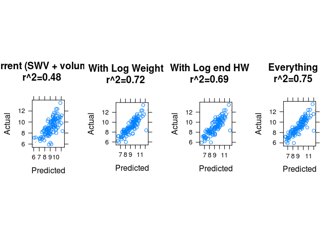

```
##
## Call:
## lm(formula = E.avg.dyn ~ SWV + m_volume, data = L, subset = !is.na(L$m_sed))
##
## Residuals:
##     Min      1Q  Median      3Q     Max
## -3.2365 -0.6130 -0.0252  0.6845  2.6291
##
## Coefficients:
##               Estimate Std. Error t value Pr(>|t|)
## (Intercept) -6.1681972  1.5528785  -3.972 0.000129 ***
## SWV          0.0044086  0.0004421   9.971  < 2e-16 ***
## m_volume     1.8252705  0.6312929   2.891 0.004647 **
## ---
## Signif. codes:  0 '***' 0.001 '**' 0.01 '*' 0.05 '.' 0.1 ' ' 1
##
## Residual standard error: 1.079 on 107 degrees of freedom
## Multiple R-squared:  0.4817, Adjusted R-squared:  0.472
## F-statistic: 49.72 on 2 and 107 DF,  p-value: 5.386e-16
##
##
## Call:
## lm(formula = E.avg.dyn ~ SWV + density + m_volume + hw.vfrac,
##     data = L, subset = !is.na(L$m_sed))
##
## Residuals:
##     Min      1Q  Median      3Q     Max
## -3.8537 -0.3722  0.0763  0.4953  1.8764
##
## Coefficients:
##               Estimate Std. Error t value Pr(>|t|)
## (Intercept) -1.466e+01  2.309e+00  -6.347 5.68e-09 ***
## SWV          5.170e-03  3.414e-04  15.146  < 2e-16 ***
## density      7.391e-03  1.927e-03   3.834 0.000215 ***
## m_volume     1.121e+00  4.752e-01   2.360 0.020128 *
## hw.vfrac    -2.720e+00  1.277e+00  -2.130 0.035542 *
## ---
## Signif. codes:  0 '***' 0.001 '**' 0.01 '*' 0.05 '.' 0.1 ' ' 1
##
## Residual standard error: 0.802 on 105 degrees of freedom
```

[output cut: 35 more lines]

```
## Coefficients:
##                Estimate Std. Error t value Pr(>|t|)
## (Intercept)  -1.284e+01  2.340e+00  -5.486 2.96e-07 ***
## SWV           4.923e-03  3.376e-04  14.583  < 2e-16 ***
## density       6.447e-03  1.890e-03   3.412 0.000924 ***
## m_a2          6.458e-03  2.759e-03   2.340 0.021205 *
## hw.vfrac     -3.054e+00  1.275e+00  -2.394 0.018475 *
## m_led         2.272e-03  1.172e-03   1.937 0.055445 .
## m_whorliness -5.163e-01  2.709e-01  -1.906 0.059419 .
## ---
## Signif. codes:  0 '***' 0.001 '**' 0.01 '*' 0.05 '.' 0.1 ' ' 1
##
## Residual standard error: 0.7673 on 103 degrees of freedom
## Multiple R-squared:  0.7478, Adjusted R-squared:  0.7331
## F-statistic: 50.91 on 6 and 103 DF,  p-value: < 2.2e-16
```

```r
myplot=function (m, lbl) {
  print(s<-summary(m))
  xyplot(m$model$E.avg.dyn ~ predict(m),
         panel=function(x,y,...) {
           panel.abline(c(0,1), col='grey70', lty=2)
           panel.xyplot(x,y,...)},
          aspect='iso',
         xlab='Predicted', ylab='Actual',
         main=sprintf('%s\nr^2=%0.2f',lbl,s$r.squared))
         #main=lbl, sub=expression(r^2==s$r.squared))
}
library(gridExtra)
grid.arrange(myplot(m.best.current, lbl="Current (SWV + volume)"),
             myplot(m.best.withWeight, lbl="With Log Weight"),
             myplot(m.best.withHW, lbl="With Log end HW"),
             myplot(m.best, lbl="Everything"),
             nrow=1,
             as.table=TRUE)
```

*Does eliminating logs with significant compression wood visible on ends lead to better models?*

## Warp

### Per Log Distributions

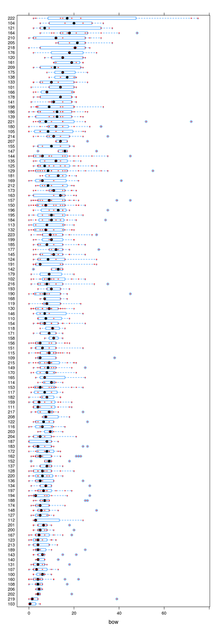

```r
bwpanel=function(...){
          panel.bwplot(...)
          panel.points(...,col='red', cex=0.3)
        }
bwplot( factor(SWILogNumber,levels=L$SWILogNumber[order(L$bow_75)],ordered=TRUE) ~ bow, B, panel=bwpanel)
```

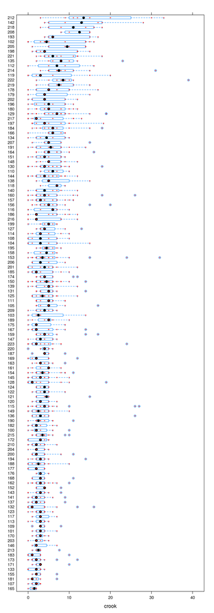

```r
bwplot( factor(SWILogNumber,levels=L$SWILogNumber[order(L$crook_75)],ordered=TRUE) ~ crook, B, panel=bwpanel)
```

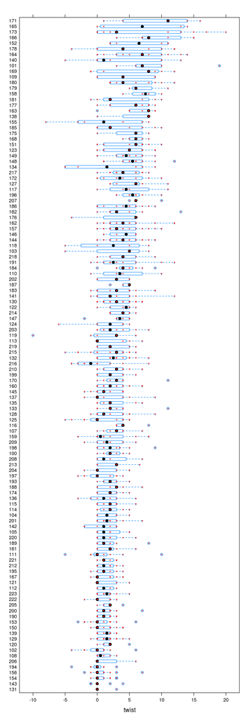

```r
bwplot( factor(SWILogNumber,levels=L$SWILogNumber[order(L$twist_75)],ordered=TRUE) ~ twist, B, panel=bwpanel)
```

### Best Linear Models

Use stepwise regression to select ‘best’ (in terms of AIC) linear model.

```r
best.linear.model = function (y,LL=NULL) {
  if (is.null(LL)) {
    predictors = c('SWV',
          'm_volume','m_led','m_sed',
          'm_a0','m_a1','m_a2','m_taper','m_waist',
          'm_ovality','m_whorliness',
          'm_sweep1','m_sweep2',
          'weight','density',
          'hw.vfrac','sweep.prod')
    LL=L[,predictors]
  }
  LL$y = y
  LL = na.omit(LL)#[complete.cases(LL),]
  scope = formula(paste("y~",paste(predictors,collapse='+')))
  #print(scope)
  m <- step(lm(y ~ SWV, LL), direction="both", scope=scope, trace=0)
  print(xyplot(LL$y ~ predict(m),aspect='iso',panel=function(...){
    panel.abline(c(0,1),col='grey70')
    panel.xyplot(...)
  },
  main=deparse(substitute(y)),
  xlab='predicted', ylab='observed'))

  return(m)
}
```

#### Bow

```r
summary(m.best.bow_avg <- best.linear.model(L$bow_avg))
```

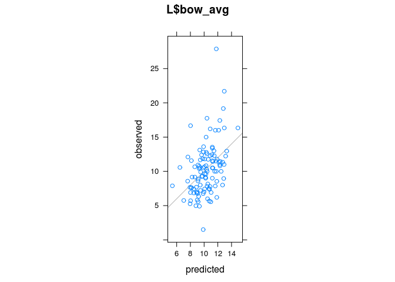

```
##
## Call:
## lm(formula = y ~ SWV + density + m_taper + m_whorliness, data = LL)
##
## Residuals:
##     Min      1Q  Median      3Q     Max
## -8.3691 -2.2349 -0.4538  1.6654 16.0980
##
## Coefficients:
##               Estimate Std. Error t value Pr(>|t|)
## (Intercept)  48.501185   7.972952   6.083 1.94e-08 ***
## SWV          -0.006148   0.001506  -4.083 8.70e-05 ***
## density      -0.014984   0.005031  -2.978   0.0036 **
## m_taper      -0.222586   0.131070  -1.698   0.0924 .
## m_whorliness -2.041574   1.258311  -1.622   0.1077
## ---
## Signif. codes:  0 '***' 0.001 '**' 0.01 '*' 0.05 '.' 0.1 ' ' 1
##
## Residual standard error: 3.451 on 105 degrees of freedom
## Multiple R-squared:  0.189,  Adjusted R-squared:  0.1581
## F-statistic: 6.119 on 4 and 105 DF,  p-value: 0.0001824
```

```r
summary(m.best.bow_50 <- best.linear.model(L$bow_50))
```

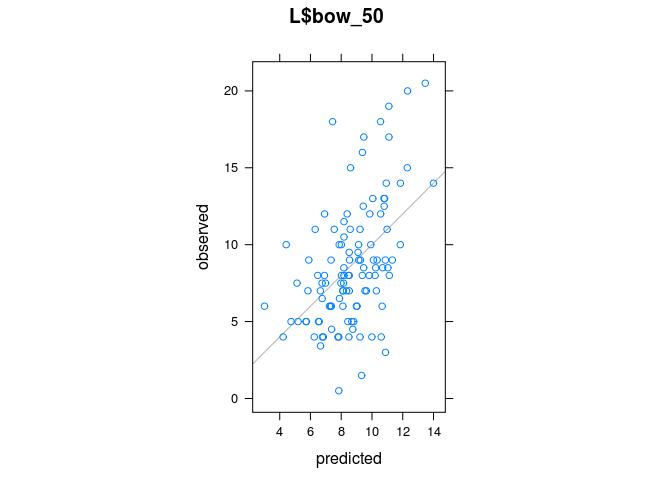

```
##
## Call:
## lm(formula = y ~ SWV + m_whorliness + weight + m_sed, data = LL)
##
## Residuals:
##     Min      1Q  Median      3Q     Max
## -7.8776 -2.2011 -0.2556  2.1400 10.5632
##
## Coefficients:
##               Estimate Std. Error t value Pr(>|t|)
## (Intercept)  23.179203   5.754269   4.028 0.000107 ***
## SWV          -0.006767   0.001578  -4.287 4.03e-05 ***
## m_whorliness -3.944875   1.202708  -3.280 0.001409 **
## weight       -0.038237   0.009623  -3.974 0.000130 ***
## m_sed         0.087509   0.025646   3.412 0.000916 ***
## ---
## Signif. codes:  0 '***' 0.001 '**' 0.01 '*' 0.05 '.' 0.1 ' ' 1
##
## Residual standard error: 3.541 on 105 degrees of freedom
## Multiple R-squared:  0.245,  Adjusted R-squared:  0.2162
## F-statistic: 8.518 on 4 and 105 DF,  p-value: 5.422e-06
```

```r
summary(m.best.bow_75 <- best.linear.model(L$bow_75))
```

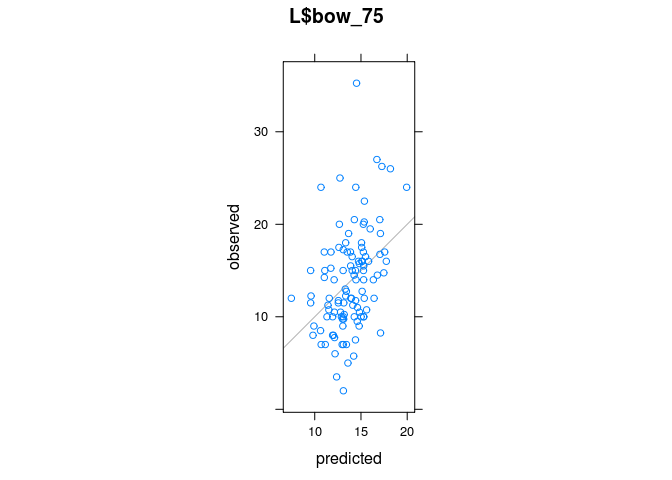

```
##
## Call:
## lm(formula = y ~ SWV + m_taper + density, data = LL)
##
## Residuals:
##      Min       1Q   Median       3Q      Max
## -11.0984  -3.3291  -0.6175   3.0863  20.7276
##
## Coefficients:
##              Estimate Std. Error t value Pr(>|t|)
## (Intercept) 59.433708  11.481376   5.177 1.08e-06 ***
## SWV         -0.007701   0.002218  -3.472 0.000748 ***
## m_taper     -0.548397   0.179534  -3.055 0.002851 **
## density     -0.016005   0.007296  -2.194 0.030449 *
## ---
## Signif. codes:  0 '***' 0.001 '**' 0.01 '*' 0.05 '.' 0.1 ' ' 1
##
## Residual standard error: 5.089 on 106 degrees of freedom
## Multiple R-squared:  0.1527, Adjusted R-squared:  0.1288
## F-statistic: 6.369 on 3 and 106 DF,  p-value: 0.0005193
```

SWV, weight, density, whorliness and taper best predictors. Median bow best predicted.